# Homework Assignment 1

Introduction to R programming

Danilo Cardoso dos Santos `dcardoso8563@floridapoly.edu`

# Problem 1

(spuRs, chapter 2, exercise 2d)

Give R an expression that returns the following matrix

$$\begin{align*}
A & =\left[\begin{array}{ccc}
0 & 2 & 3\\
0 & 5 & 0\\
7 & 0 & 0
\end{array}\right]
\end{align*}$$

```r
elem <- c(0,2,3,0,5,0,7,0,0)
A <- matrix(elem,3,3,T)

A
```

```
     [,1] [,2] [,3]
[1,]    0    2    3
[2,]    0    5    0
[3,]    7    0    0
```

# Problem 2

(spuRs, chapter 2, exercise 4)

Use R to produce a vector containing all integers from 1 to 100 that are *not divisible* by 2, 3, or 7.

```r
# Function
not_div <- function(x,y,z) {
    d <- 1:100
    x <- d[d %% x != 0]
    y <- d[d %% y != 0]
    z <- d[d %% z != 0]
  out1 <- c(x)
  out2 <- c(y)
  out3 <- c(z)
  print(out1)
  print(out2)
  print(out3)
}
#Output

not_div(2,3,7)
```

```
 [1]  1  3  5  7  9 11 13 15 17 19 21 23 25 27 29 31 33 35 37 39 41 43 45 47 49 51 53 55 57 59
[31] 61 63 65 67 69 71 73 75 77 79 81 83 85 87 89 91 93 95 97 99
 [1]   1   2   4   5   7   8  10  11  13  14  16  17  19  20  22  23  25  26  28  29  31  32
[23]  34  35  37  38  40  41  43  44  46  47  49  50  52  53  55  56  58  59  61  62  64  65
[45]  67  68  70  71  73  74  76  77  79  80  82  83  85  86  88  89  91  92  94  95  97  98
[67] 100
 [1]   1   2   3   4   5   6   8   9  10  11  12  13  15  16  17  18  19  20  22  23  24  25
[23]  26  27  29  30  31  32  33  34  36  37  38  39  40  41  43  44  45  46  47  48  50  51
[45]  52  53  54  55  57  58  59  60  61  62  64  65  66  67  68  69  71  72  73  74  75  76
[67]  78  79  80  81  82  83  85  86  87  88  89  90  92  93  94  95  96  97  99 100
```

# Problem 3

(spuRs, chapter 3, exercise 1)

Consider the function $f(x)$ defined by

| $x$ | $\leq 0$ | $\in(0, 1]$ | $>1$ |
| --- | --- | --- | --- |
| $f(x)$ | $-x^3$ | $x^2$ | $\sqrt{x}$ |

Supposing that you are given `x`, write an R expression for `y` using *if statements*

Add your expression for `y` to the following program, then run it to plot the function `f`.

**Change the option `eval = FALSE` to `eval = TRUE`**

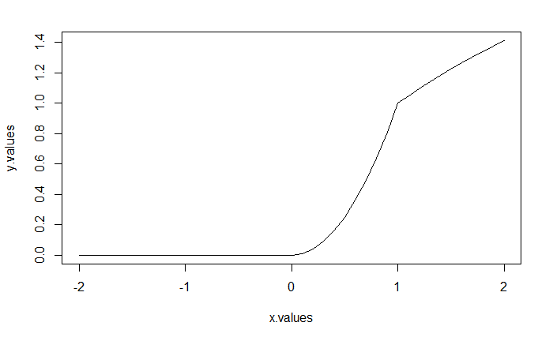

```r
# input
x.values <- seq(-2, 2, by = 0.1)
# for each x calculate y
n <- length(x.values)
y.values <- rep(0, n)
y = 0
for (i in 1:n) {
       x <- x.values[i]
       y <- y.values[i
                     ]
       if(x == 0) {
         y <- -x^3
       } else if(x > 0 && x <=1) {
         y <- x^2
       } else if(x > 1) {
         y <- sqrt(x)
       }
       y.values[i] <- y
}

# output
plot(x.values, y.values, type = "l")
```

- Do you think $f$ has a derivative at 1? What about at 0?

- We remark that it is possible to vectorise the program above, using the `ifelse()` function.

# Problem 4

(spuRs, chapter 3, exercise 5)

To rotate a vector $(x,y)^T$ anticlockwise by $\theta$ radians, you premultiply it by the matrix

$$\begin{align*}
B & =\left[\begin{array}{cc}
\cos(\theta) & -\sin(\theta)\\
\sin(\theta) & \cos(\theta)
\end{array}\right]
\end{align*}$$

Write a program in R that does this for you.

```r
rotate <- function(x) {
    theta <- pi/4
    B <- matrix(c(cos(theta), sin(theta), -sin(theta), cos(theta)),2,2)
    B %*% x
}

my_vec <- matrix(c(1,0),2,1)

vec_rot <- rotate(my_vec)

vec_rot
```

```
          [,1]
[1,] 0.7071068
[2,] 0.7071068
```

# Problem 5

(spuRs, chapter 3, exercise 2)

Let $h(x,n) = 1 + x + x^2 + ... + x^n = \sum _{i=0} ^n x^i.$ Write an R program to calculate $h(x,n)$ using a `for` loop.

```r
h <- function(x,n) {
    result <- vector("numeric")
      for (i in 0:n) {
      y <- x^i
      result[i] <- y
            }
print(sum(result)+1)
  }
```

# Problem 6

(spuRs, chapter 3, exercise 3)

The function $h(x,n)$ in the previous problem is the finite sum of a *geometric sequence*. It has the following explicit formula (for $x \neq 1$)

$$h(x, n) = \frac{1-x^{n+1}}{1-x}$$

Test your program from the previous problem against this formula using the following values of $x$ and $n$:

| $x$ | $n$ | $h(x,n)$ |
| --- | --- | --- |
| 0.3 | 55 | 1.428571 |
| 6.6 | 8 | 4243335.538 |

(use R to calculate the formula)

```r
f_t <- h(0.3,55)
```

```
[1] 1.428571
```

```r
s_t <- h(6.6,8)
```

```
[1] 4243336
```

```r
el <- c(0.3,55,f_t,6.6,8,s_t)


R <- matrix(el, 2,3, T)

colnames(R) <- (c('x','n','h(x,n)'))

R
```

```
       x  n       h(x,n)
[1,] 0.3 55 1.428571e+00
[2,] 6.6  8 4.243336e+06
```